# TDDE07 - Lab 4

Pontus Svensson (ponsv690) & Kristian Sikiric (krisi211)

# Assignment 1

### Time series models in Stan

A function was written to simulate data from the AR(1)-process $x_t = \mu + \phi (x_{t-1} - \mu) + \epsilon_t, \epsilon_t \sim N(0,\sigma^2)$, with $\mu=10, \sigma^2=2, T=200$ and $t=2,3, ...,T$. The vector $x_{1:T}$ containing all time points was returned. Simulations for values of $\phi$ between -1 and 1 were performed to show the effect of $\phi$. The plots below show that a high positive $\phi$ makes the AR(1)-process only depend on previous values, making the process follow temporary trends. When $\phi=0$, the values oscillates around the mean. With a $\phi$ close to -1, the values oscillates quicker around the mean than larger values of $\phi$.

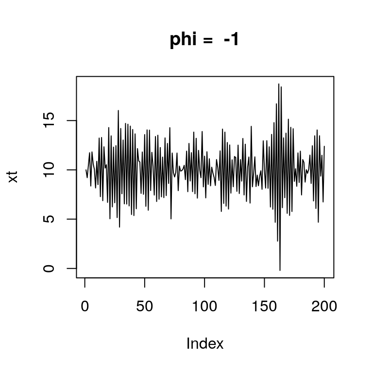

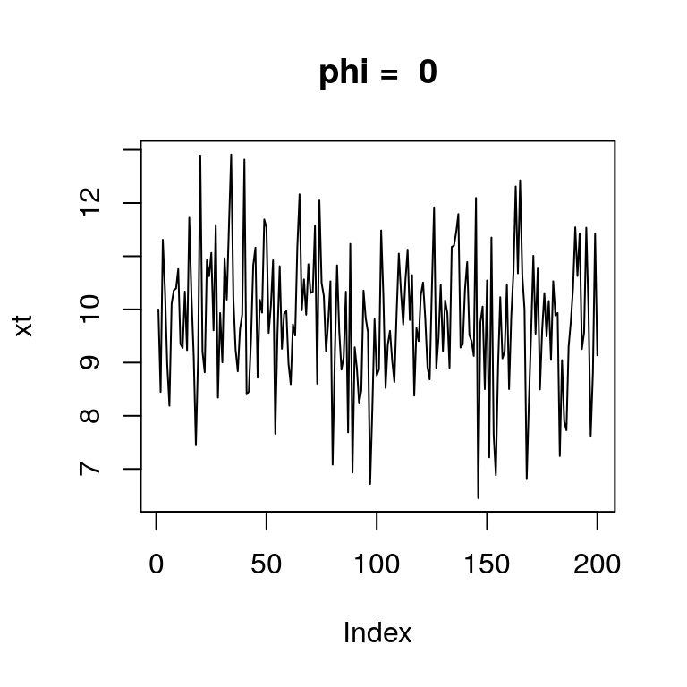

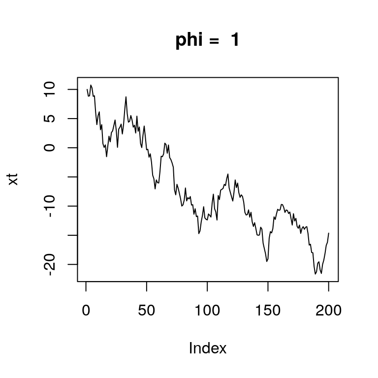

Next, two AR(1)-processes were simulated, one with $\phi=0.3$ and one with $\phi=0.95$. These were used in Stan to estimate the values of $\mu, \phi$ and $\sigma^2$ using MCMC.

Below is the posterior mean, 95% credible interval and number of effective samples for the three parameters. Along with a plot showing the convergence of the sampler. As we can see, when $\phi = 0.95$ the sampler have a hard time converging. We also see that we are close to sampling the true values. Also worth mentionning is that the effective samples for y are very few, meaning that the samples are correlated. This makes sense since $\phi$ is large, so the samples depend heavily on the previous sample.

```
## [1] "Parameters for x"
```

```
## Inference for Stan model: 3118d30d9147b2cf56d6b63fb0063ccd.
## 4 chains, each with iter=2000; warmup=1000; thin=1;
## post-warmup draws per chain=1000, total post-warmup draws=4000.
##
##          mean se_mean    sd  2.5%  97.5% n_eff Rhat
## mu     10.002   0.003 0.158 9.683 10.309  3283    1
## sigma2  2.111   0.004 0.220 1.708  2.577  3540    1
## phi     0.341   0.001 0.071 0.201  0.478  3318    1
##
## Samples were drawn using NUTS(diag_e) at Mon May 20 15:02:12 2019.
## For each parameter, n_eff is a crude measure of effective sample size,
## and Rhat is the potential scale reduction factor on split chains (at
## convergence, Rhat=1).
```

```
##
## Parameters for y
```

```
## Inference for Stan model: 3118d30d9147b2cf56d6b63fb0063ccd.
## 4 chains, each with iter=2000; warmup=1000; thin=1;
## post-warmup draws per chain=1000, total post-warmup draws=4000.
##
##          mean se_mean     sd    2.5%  97.5% n_eff  Rhat
## mu     10.934   5.949 24.182 -44.260 86.445    17 1.299
## sigma2  2.085   0.015  0.211   1.696  2.505   205 1.020
## phi     0.974   0.003  0.025   0.917  1.005    96 1.066
##
## Samples were drawn using NUTS(diag_e) at Mon May 20 15:02:15 2019.
## For each parameter, n_eff is a crude measure of effective sample size,
## and Rhat is the potential scale reduction factor on split chains (at
## convergence, Rhat=1).
```

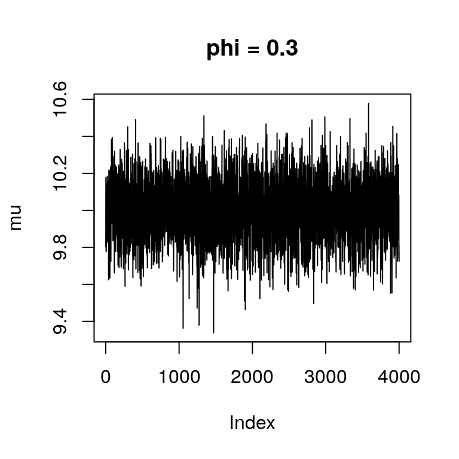

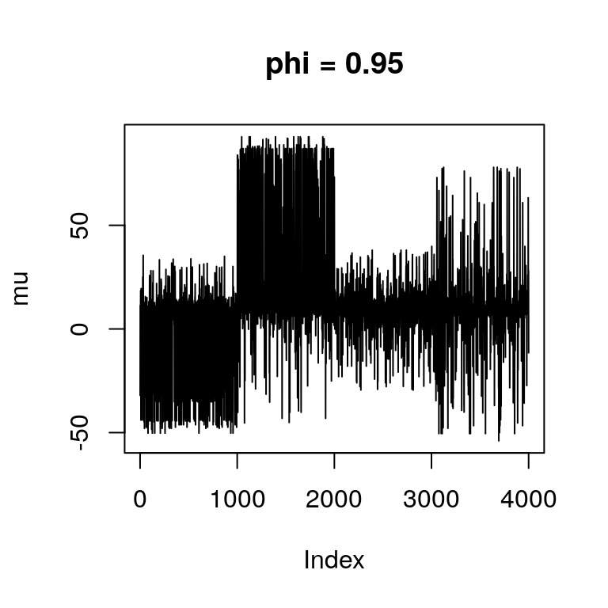

Below are two plots showing the joint posterior of $\phi$ and $\mu$ for the two samplers. We see that $\mu$ varies more and more when $\phi$ is close to one.

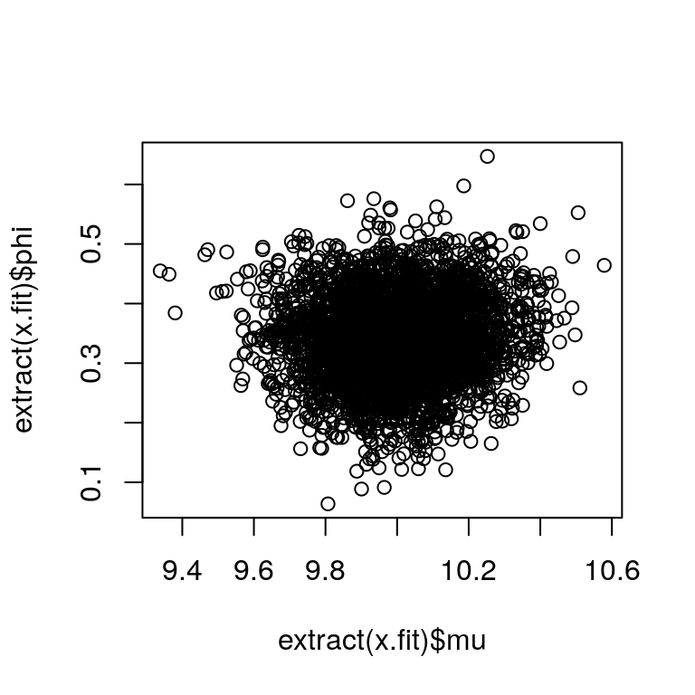

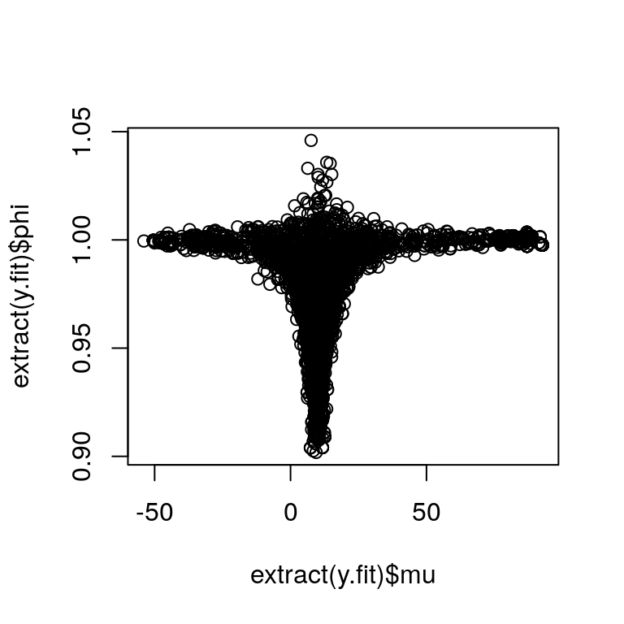

Now a dataset containing the number of cases of campylobacter infections was used. It was assumed that the number of infections $c_t$ at each time point followed an independent Poisson distribution when conditioned on a latent AR(1)-process $x_t$, $c_t|x_t \sim Poisson(exp(x_t))$. The simulation was done in Stan again, we only used the prior that $\phi$ is between -1 and 1. Below is the plot of the posterior mean and 95% credible intervals for the latent intensity $\theta_t = exp(x_t)$.

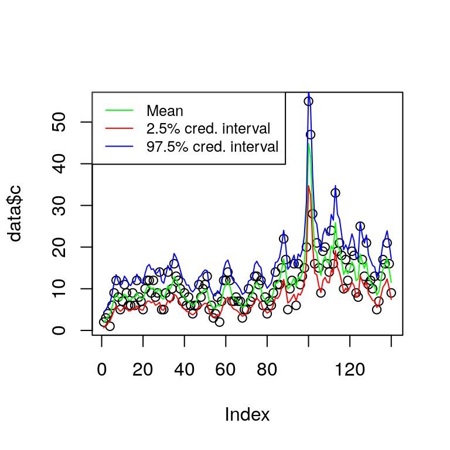

The assignment above was repeated but with a different prior of $\sigma^2$. $\sigma^2$ was supposed to be small, so we used a scaled inverse chi squared distribution to get a small $\sigma^2$. The following plot shows the new result.

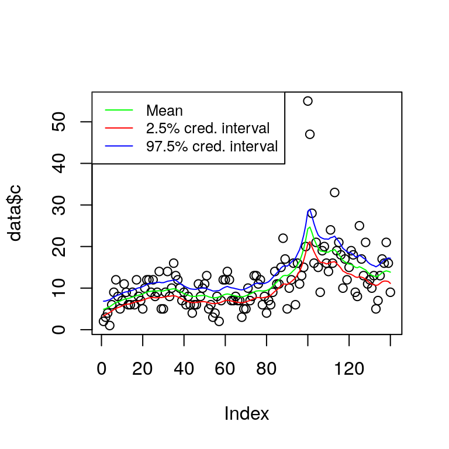